# Experimental Design

Alan T. Arnholt

September 16, 2019

# 1 Completely Randomized Design

## 1.1 Motivational Example Tires

A tire manufacturer is interested in investigating the handling properties for different tread patterns. The data frame **TIRE** has the stopping distances measured to the nearest foot for a standard-sized car to come to a complete stop from a speed of 60 miles per hour. THere are six measurements of the stopping distance for four different tread patterns labeled A, B, C, and D. THe same driver and car were used for all 24 measurements. While the numbers in **TIRE** do not reveal the randomization scheme used for the experiment, the order of treatments was assigned at random.

One way to ensure treatments are randomly assigned to the 24 runs is to use a random number generator. This can be accomplished with R by typing

```r
population <- rep(LETTERS[1:4], 6)
set.seed(4)
Treatment <- sample(population, size = 24, replace = FALSE)
DF <- data.frame(Run = 1:24, Treatment)
DF
```

```
   Run Treatment
1    1         C
2    2         A
3    3         C
4    4         B
5    5         A
6    6         A
7    7         B
8    8         D
9    9         D
10  10         B
11  11         C
12  12         D
13  13         D
14  14         B
15  15         C
16  16         B
17  17         D
18  18         A
19  19         A
20  20         A
21  21         C
22  22         B
23  23         D
24  24         C
```

Another fashion to obtain a randomization scheme is to use the **agricolae** package.

```r
library(agricolae)
design.crd(trt = LETTERS[1:4], r = 6, seed = 4)
```

```
$parameters
$parameters$design
[1] "crd"

$parameters$trt
[1] "A" "B" "C" "D"

$parameters$r
[1] 6 6 6 6

$parameters$serie
[1] 2

$parameters$seed
[1] 4

$parameters$kinds
[1] "Super-Duper"

$parameters[[7]]
[1] TRUE


$book
   plots r LETTERS[1:4]
1    101 1            B
2    102 1            C
3    103 1            A
4    104 1            D
5    105 2            D
6    106 3            D
7    107 2            A
8    108 4            D
9    109 5            D
10   110 2            C
11   111 3            C
12   112 2            B
13   113 3            A
14   114 3            B
15   115 4            C
16   116 5            C
17   117 4            A
18   118 5            A
19   119 4            B
20   120 6            D
21   121 5            B
22   122 6            C
23   123 6            A
24   124 6            B
```

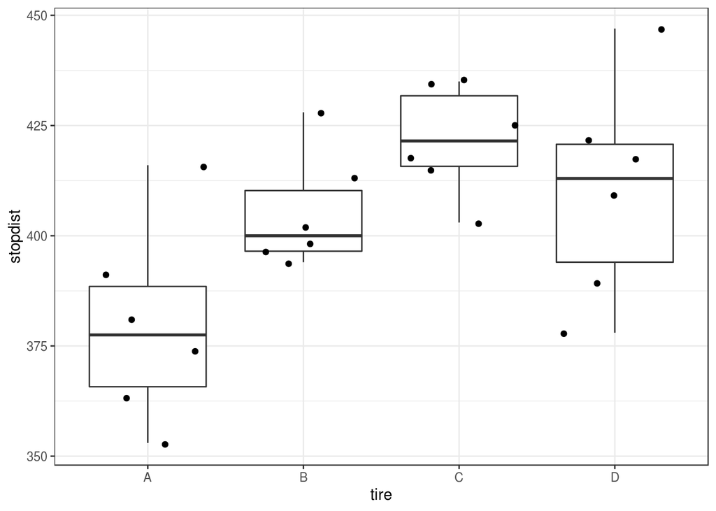

Figure 1.1: Side-by-side boxplots of stopping distance by tire type

```r
library(PASWR2)
library(ggplot2)
ggplot(data = TIRE, aes(x = tire, y = stopdist)) +
  geom_boxplot() +
  geom_jitter() +
  theme_bw()
```

From the boxplots in Figure 1.1, it appears that there are differences in stopping distances based on different tire treads. At this point, it would be nice to formalize the last sentence with an inferential procedure. It is initially tempting to many to perform pairwise $t$-tests on all six $\left(\binom{4}{2}=6\right)$ of the pairwise differences; however, this should not be done! If the probability of correctly accepting the null hypothesis is $1- \alpha = 0.95$, then the probability of correctly accepting the null hypothesis for all six pairwise tests assuming independence among tests would be $(0.95)^6=0.74$. The type I error rate is not 5% but 26.49% in this case. Of course, the more treatments that are compared, the more likely one is to make a type I error. What would the type I error rate be if the individual error rate for a single comparison is 5% and seven treatments were compared? (Answer: 65.94%) The appropriate procedure for testing the equality of several means is analysis of variance, which is introduced in the context of a completely randomized design.

**Completely Randomized Design** The simplest randomized design for comparing several treatments is the completely randomized design (CRD). CRDs have $a \ge 2$ treatments to compare and $N$ experimental units. Each treatment is applied to $n_i$ $(i=1, 2, \dots, a)$ experimental units, where $n_1 + n_2 + \dots +n_a = N$. In order to conduct the experiment, the researcher randomly assigns treatments to the experimental units (design structure). Although the sizes of the $a$ samples need not be identical, the power of the test is maximized when $n_1=n_2= \dots =n_a$ for the $a$ treatments. On each experimental unit, a response variable $Y$ is measured. In Section 1.1, $Y$ represents the distance to the nearest foot required to stop a particular model of car traveling at 60 miles per hour using four different brands of tires. The CRD, when there is one factor with $a$ levels (treatments) and no assumed relationships among the $a$ levels, is called a **one-way treatment** structure. Notation is critical, and the following conventions are used throughout the chapter. The sum of the observations in the $i^\text{th}$ treatment group is $Y_{i\bullet}=\sum_{j=1}^{n_i} Y_{ij}$, and the mean of the observations in the $i^\text{th}$ treatment group is $\bar{Y}_{i\bullet}=\frac{1}{n_{i}}\sum_{j=1}^{n_i}Y_{ij} = \frac{Y_{i\bullet}}{n_i}$. The bar indicates a mean while the dot $(\bullet)$ indicates that values have been added over the indicated subscript. The sum of all observations is $Y_{\bullet\bullet}=\sum_{i=1}^a \sum_{j=1}^{n_i}Y_{ij}.$ The grand mean of all observations is denoted $\bar{Y}_{\bullet\bullet}=\frac{1}{N}\sum_{i=1}^a\sum_{j=1}^{n_i}Y_{ij}=\frac{Y_{\bullet\bullet}}{N}.$

To describe the observations, the linear statistical model
$$\begin{equation}
Y_{ij} = \mu + \tau_i + \epsilon_{ij} \text{ for }i=1, 2, \dots, a \text{ and } j
=1, 2, \dots, n_a
\tag{1.1}
\end{equation}$$

is used, where $Y_{ij}$ is the $j^\text{th}$ observation of the $i^\text{th}$ treatment, $\mu$ is a parameter common to all treatments called the overall mean, $\tau_i$ is a parameter unique to the $i^\text{th}$ treatment called the $i^\text{th}$ treatment effect, and $\epsilon_{ij}$ is a random error component. For hypothesis testing, the model errors are assumed to be normally and independently distributed with mean zero and constant standard deviation $\bigl(NID(0, \sigma)\bigr)$. The careful reader will realize that this implies the variance is assumed to be constant for all $a$ treatments.

## A different approach for R Code 11.1

```r
library(dplyr)
GM <- TIRE %>%
  summarize(Mean = mean(stopdist))
GM$Mean  # Grand Mean Y_{dot, dot}
```

```
[1] 404.2083
```

```r
TMs <-  TIRE %>%
        group_by(tire) %>%
        summarize(TreatMeans = mean(stopdist))
TMs     #  Treament Means
```

```
# A tibble: 4 x 2
  tire  TreatMeans
  <fct>      <dbl>
1 A           380.
2 B           405.
3 C           422.
4 D           410.
```

```r
a <- dim(TMs)[1]
N <- length(TIRE$stopdist)
df.treat <- a - 1
df.error <- N - a
n_i <- TIRE %>%
          group_by(tire) %>%
          count()
n_i
```

```
# A tibble: 4 x 2
# Groups:   tire [4]
  tire      n
  <fct> <int>
1 A         6
2 B         6
3 C         6
4 D         6
```

```r
n <- n_i[1, 2]
SStreat <- n*sum((TMs$TreatMeans - GM$Mean)^2)
SStreat
```

```
         n
1 5673.125
```

```r
SStotal <- sum((TIRE$stopdist - GM$Mean)^2)
SStotal
```

```
[1] 12771.96
```

```r
SSerror <- sum((TIRE$stopdist - rep(TMs$TreatMeans, each = 6))^2)
SSerror
```

```
[1] 7098.833
```

```r
MSerror <- SSerror/df.error
MSerror
```

```
[1] 354.9417
```

```r
MStreat <- SStreat/df.treat

Fobs <- MStreat/MSerror
Fobs
```

```
         n
1 5.327753
```

```r
pvalue <- pf(Fobs$n, df.treat, df.error, lower = FALSE)
pvalue
```

```
[1] 0.007315521
```

```r
mod <- aov(stopdist ~ tire, data = TIRE)
mod
```

```
Call:
   aov(formula = stopdist ~ tire, data = TIRE)

Terms:
                    tire Residuals
Sum of Squares  5673.125  7098.833
Deg. of Freedom        3        20

Residual standard error: 18.8399
Estimated effects may be unbalanced
```

```r
summary(mod)
```

```
            Df Sum Sq Mean Sq F value  Pr(>F)
tire         3   5673  1891.0   5.328 0.00732 **
Residuals   20   7099   354.9
---
Signif. codes:  0 '***' 0.001 '**' 0.01 '*' 0.05 '.' 0.1 ' ' 1
```

```r
model.tables(mod, type = "means")
```

```
Tables of means
Grand mean

404.2083

 tire
tire
    A     B     C     D
379.7 405.2 421.7 410.3
```

```r
model.tables(mod, type = "effects")
```

```
Tables of effects

 tire
tire
      A       B       C       D
-24.542   0.958  17.458   6.125
```

## 1.2 Power

**Example 11.2** Suppose the tire manufacturer believes the true mean stopping distance for tread patterns A, B, C, and D to be 390, 405, 415, and 410 feet, respectively, with a common standard deviation that could be as high as 20 feet or as small as 10 feet. Assume sets of tires are put on the car (a single car is used for all tests to reduce variability) in random order.

- Suppose the manufacturer wants to test $H_0 : \mu_B - \mu_A = 0$ versus $H_1 : \mu_B - \mu_A > 0$ using $\alpha = 0.05$, assuming $\sigma = 10$. Determine the power of the test if six sets of tires with each tread are available.

```r
HypMeans <- c(405, 390)
a <- length(HypMeans)
n <- 6
N <- a*n
df.error <- N - a
Sigma <- 10
alpha <- 0.05
Y <- rep(HypMeans, each = 6)
Treat <- factor(rep(LETTERS[c(2, 1)], each = 6))
summary(aov(Y ~ Treat))
```

```
            Df Sum Sq Mean Sq   F value Pr(>F)
Treat        1    675     675 7.385e+28 <2e-16 ***
Residuals   10      0       0
---
Signif. codes:  0 '***' 0.001 '**' 0.01 '*' 0.05 '.' 0.1 ' ' 1
```

```r
SStreat <- summary(aov(Y ~ Treat))[[1]][1, 2]
lambda <- SStreat/Sigma^2
lambda
```

```
[1] 6.75
```

```r
Gamma <- sqrt(lambda)
CritT <- qt(1 - alpha, df.error)
Power <- pt(CritT, df.error, ncp = Gamma, lower = FALSE)
Power
```

```
[1] 0.7798662
```

```r
####
power.t.test(n = 6, delta = 15, sd = Sigma, alternative = "one.sided")
```

```
     Two-sample t test power calculation

              n = 6
          delta = 15
             sd = 10
      sig.level = 0.05
          power = 0.7798662
    alternative = one.sided

NOTE: n is number in *each* group
```

```r
####
library(pwr)
pwr.t.test(n = 6, d = 15/Sigma, sig.level = 0.05,
           type = "two.sample", alternative = "greater")
```

```
     Two-sample t test power calculation

              n = 6
              d = 1.5
      sig.level = 0.05
          power = 0.7798662
    alternative = greater

NOTE: n is number in *each* group
```

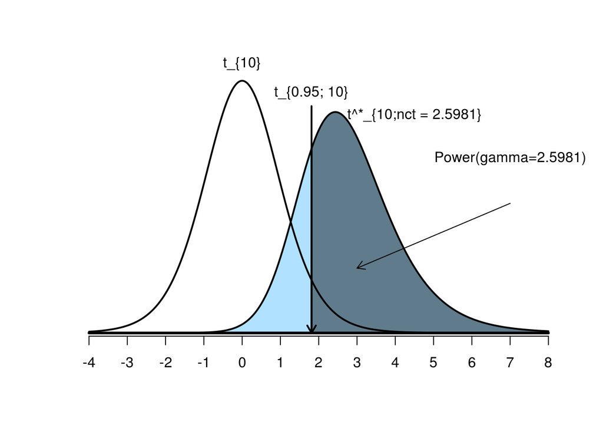

- Determine the probability that differences among the means will be detected using $\alpha = 0.05$ assuming $\sigma = 20$ feet if six sets of tires with each tread are available. Simulate the non-central F distribution and compute the power by simulation. How does the simulation compare to the theoretical answer?

```r
alpha <- 0.05
n <- 6
HypMeans <- c(390, 405, 415, 410)   # Hypothesized means
a <- length(HypMeans)               # Number of groups
N <- a*n                            # Total number of expt. units
df.error <- N - a                   # DOF error
Sigma <- 20
Y <- rep(HypMeans, each = n)                    # Responses
Treat <- factor(rep(LETTERS[1:4], each = 6))    # Treatment factor
SStreat <- summary(aov(Y ~ Treat))[[1]][1, 2]   # SS treatment
lambda <- SStreat/Sigma^2
lambda
```

```
[1] 5.25
```

```r
CritF <- qf(1 - alpha, a - 1, N - a)
CritF
```

```
[1] 3.098391
```

```r
TheoPower <- pf(CritF, a - 1, N - a, lambda, lower = FALSE)
TheoPower
```

```
[1] 0.3862415
```

```r
## OR
power.anova.test(groups = 4, n = 6, between.var = var(HypMeans),
                 within.var = Sigma^2, sig.level = 0.05)
```

```
     Balanced one-way analysis of variance power calculation

         groups = 4
              n = 6
    between.var = 116.6667
     within.var = 400
      sig.level = 0.05
          power = 0.3862415

NOTE: n is number in each group
```

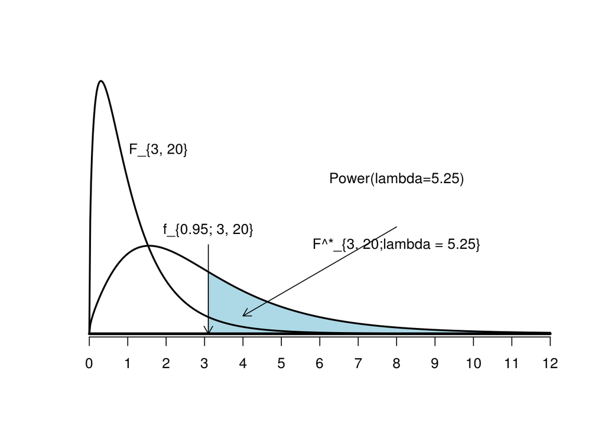

Simulation Now

```r
set.seed(10)
a <- 4            # Number of groups
n <- 6            # Number in each group
alpha <- 0.05     # Alpha level
N <- a*n          # Total numberof expt. units
CritF <- qf(1 - alpha, a - 1, N - a)   # Critical F value
mu1 <- 390; mu2 <- 405; mu3 <- 415; mu4 <- 410  # True means
sigma <- 20                    # Assumed sigma
SIMS <- 10^4                   # Numer of simulations
FS <- numeric(SIMS)            # Storage for FS
for(i in 1:SIMS){
  y1 <- rnorm(n, mu1, sigma)   # Values from mu1, sigma
  y2 <- rnorm(n, mu2, sigma)   # Values from mu2, sigma
  y3 <- rnorm(n, mu3, sigma)   # Values from mu3, sigma
  y4 <- rnorm(n, mu4, sigma)   # Values from mu4, sigma
  Y <- c(y1, y2, y3, y4)       # Combined reponses
  treat <- factor(rep(LETTERS[1:4], each = n))  # Treatment factor
  FS[i] <- summary(aov(Y ~ treat))[[1]][1, 4]   # F values
}
SimPower <- mean(FS > CritF)   # Simulated power
SimPower
```

```
[1] 0.3939
```